# RTA

```
Road_surface_conditions   Dry  Flood over 3cm. deep  Snow  Wet or damp
Accident_severity
Fatal injury              121                     0     0           37
Serious Injury           1332                     0     4          407
Slight Injury            7887                     2    66         2460
```

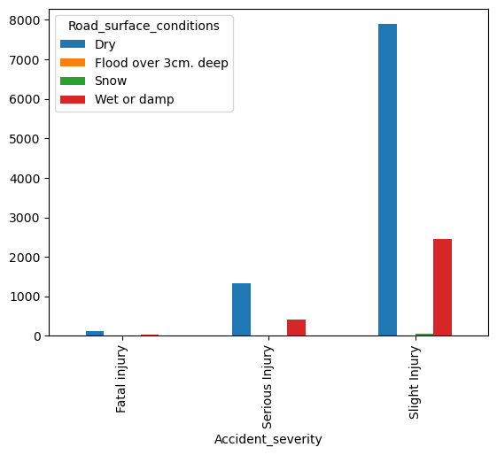

```python
CrosstabResult=pd.crosstab(index=df['Accident_severity'],columns=df['Road_surface_conditions'])
print(CrosstabResult)
CrosstabResult.plot.bar()
```

```
Light_conditions   Darkness - lights lit  Darkness - lights unlit  \
Accident_severity
Fatal injury                          66                        0
Serious Injury                       465                        7
Slight Injury                       2755                       33

Light_conditions   Darkness - no lighting  Daylight
Accident_severity
Fatal injury                            5        87
Serious Injury                         49      1222
Slight Injury                         138      7489
```

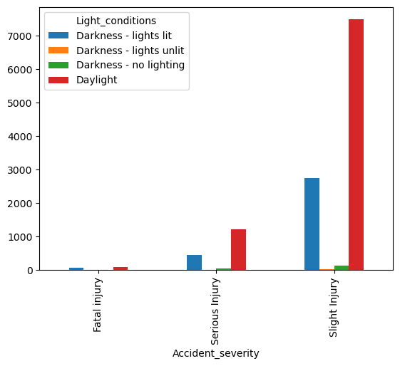

```python
CrosstabResult=pd.crosstab(index=df['Accident_severity'],columns=df['Light_conditions'])
print(CrosstabResult)
CrosstabResult.plot.bar()
```

```
Weather_conditions  Cloudy  Fog or mist  Normal  Other  Raining  \
Accident_severity
Fatal injury             0            0     135      0       23
Serious Injury           8            1    1474     28      158
Slight Injury          117            9    8454    268     1150

Weather_conditions  Raining and Windy  Snow  Unknown  Windy
Accident_severity
Fatal injury                        0     0        0      0
Serious Injury                      2     5       51     16
Slight Injury                      38    56      241     82
```

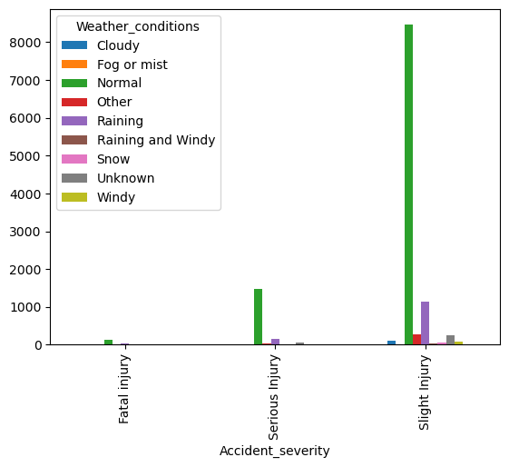

```python
CrosstabResult=pd.crosstab(index=df['Accident_severity'],columns=df['Weather_conditions'])
print(CrosstabResult)
CrosstabResult.plot.bar()
```

```
Type_of_collision  Collision with animals  Collision with pedestrians  \
Accident_severity
Fatal injury                            2                          22
Serious Injury                         27                         141
Slight Injury                         142                         733

Type_of_collision  Collision with roadside objects  \
Accident_severity
Fatal injury                                    24
Serious Injury                                 272
Slight Injury                                 1490

Type_of_collision  Collision with roadside-parked vehicles  \
Accident_severity
Fatal injury                                             0
Serious Injury                                           5
Slight Injury                                           49

Type_of_collision  Fall from vehicles  Other  Rollover  Unknown  \
Accident_severity
Fatal injury                        0      0         4        0
Serious Injury                      4      3        54        1
Slight Injury                      30     23       339       13

Type_of_collision  Vehicle with vehicle collision  With Train
Accident_severity
Fatal injury                                  106           0
Serious Injury                               1234           2
Slight Injury                                7589           7
```

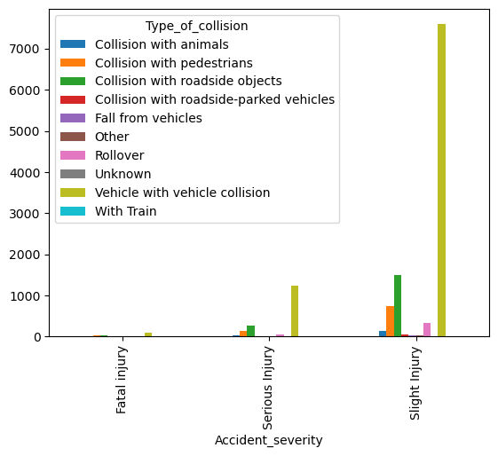

```python
CrosstabResult=pd.crosstab(index=df['Accident_severity'],columns=df['Type_of_collision'])
print(CrosstabResult)
CrosstabResult.plot.bar()
```

```
Number_of_vehicles_involved     1     2     3    4   6  7
Accident_severity
Fatal injury                   43   104    11    0   0  0
Serious Injury                519   963   210   39  12  0
Slight Injury                1434  7273  1347  324  30  7
```

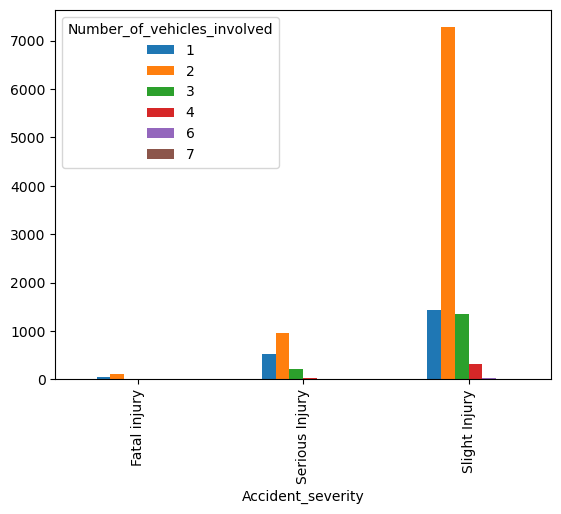

```python
CrosstabResult=pd.crosstab(index=df['Accident_severity'],columns=df['Number_of_vehicles_involved'])
print(CrosstabResult)
CrosstabResult.plot.bar()
```

```
Number_of_casualties     1     2    3    4    5   6   7  8
Accident_severity
Fatal injury            68    24   16   44    6   0   0  0
Serious Injury        1222   300  116   46   32  27   0  0
Slight Injury         7107  1966  777  304  169  62  22  8
```

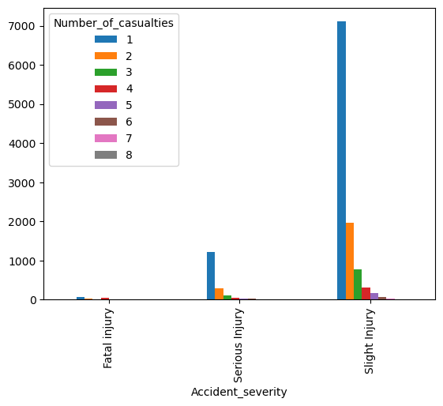

```python
CrosstabResult=pd.crosstab(index=df['Accident_severity'],columns=df['Number_of_casualties'])
print(CrosstabResult)
CrosstabResult.plot.bar()
```

```
Vehicle_movement   Entering a junction  Getting off  Going straight  \
Accident_severity
Fatal injury                         4            5             105
Serious Injury                      26           44            1191
Slight Injury                      163          290            7170

Vehicle_movement   Moving Backward  Other  Overtaking  Parked  Reversing  \
Accident_severity
Fatal injury                    12     10           5       0          7
Serious Injury                 142    130           8       2         87
Slight Injury                  831    797          83       8        469

Vehicle_movement   Stopping  Turnover  U-Turn  Unknown  Waiting to go
Accident_severity
Fatal injury              1         7       0        1              1
Serious Injury           10        77       9       13              4
Slight Injury            50       405      41       74             34
```

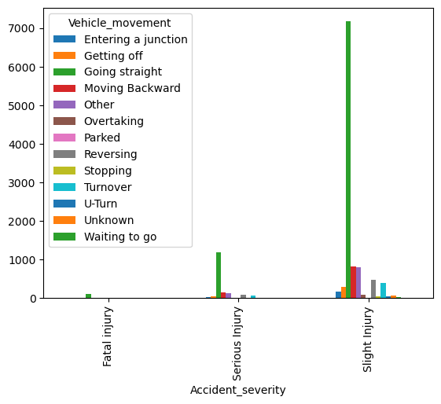

```python
CrosstabResult=pd.crosstab(index=df['Accident_severity'],columns=df['Vehicle_movement'])
print(CrosstabResult)
CrosstabResult.plot.bar()
```

```
Casualty_class     Driver or rider  Passenger  Pedestrian    na
Accident_severity
Fatal injury                    71         12          27    48
Serious Injury                 719        182         228   614
Slight Injury                 4154       1086        1394  3781
```

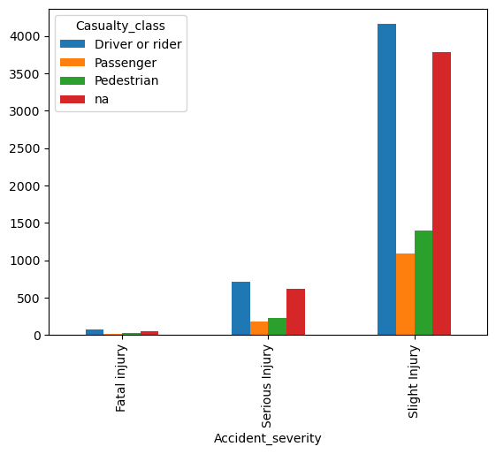

```python
CrosstabResult=pd.crosstab(index=df['Accident_severity'],columns=df['Casualty_class'])
print(CrosstabResult)
CrosstabResult.plot.bar()
```

```
Work_of_casuality  Driver  Employee  Other  Self-employed  Student  \
Accident_severity
Fatal injury          122         4      5             27        0
Serious Injury       1280        90     71            274       19
Slight Injury        7699       459    387           1743       84

Work_of_casuality  Unemployed  Unknown
Accident_severity
Fatal injury                0        0
Serious Injury              7        2
Slight Injury              26       17
```

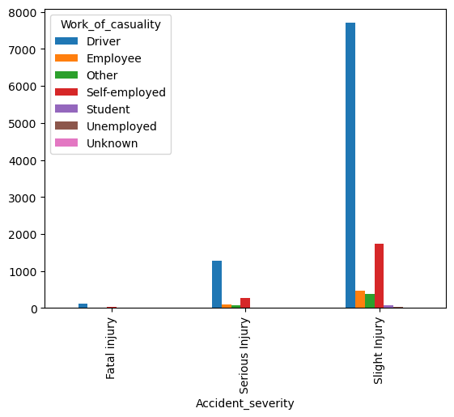

```python
CrosstabResult=pd.crosstab(index=df['Accident_severity'],columns=df['Work_of_casuality'])
print(CrosstabResult)
CrosstabResult.plot.bar()
```

```
Fitness_of_casuality  Blind  Deaf  Normal  NormalNormal  Other
Accident_severity
Fatal injury              0     0     157             0      1
Serious Injury            1     4    1730             4      4
Slight Injury            17    14   10356            15     13
```

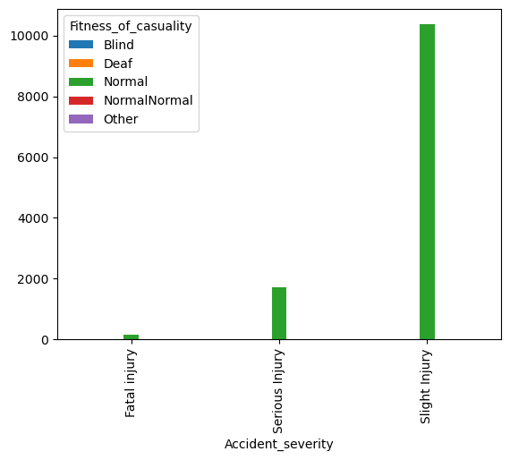

```python
CrosstabResult=pd.crosstab(index=df['Accident_severity'],columns=df['Fitness_of_casuality'])
print(CrosstabResult)
CrosstabResult.plot.bar()
```

**Insights:** - Most of the accidents happend on fridays in daylight between 11:00 AM to 8:00 PM with slight injury to most of the drivers. - The band width of age with more accidents are between 18-30 and slightly lower for 31-50 and with slight injury. - Most of the accidents which occured are of slight injuries and the conditions in which these accidents occured are in Normal weather conditions, on Dry road, on Two-way roads, near Y-shaped Junction, or because of no distancing, changing lanes from left to right or viceversa, Careless driving. - The type of vehicle with lot of accidents are Automobiles and most of the vehicles which had accident has no-defect. - Most of the accidents happend because of vehicle to vehicle collision between 2 vehicles. - Most of the people who met with an accidents are drivers with 5-10 years of experience.